# Linear Modelling Exercises

03.05.2022

For these exercises, you will need the `Howell1` dataset from the `rethinking` package. We don’t need the rest of the package, so we will just download the data directly from the package’s github repository

```r
library(data.table)
Howell1 = fread("https://github.com/rmcelreath/rethinking/raw/master/data/Howell1.csv")
```

These data, collected by anthropologist Nancy Howell in the 1960s, provide the age, height, weight, and sex sampled from a population of !Kung in Dobe (Namibia & Botswana). Note that the `male` variable is categorical, and is equal to 1 if the subject is male, and 0 if female.

1. Do some graphical data exploration. The data are multivariate, so multiple plots may be necessary.
2. Design a regression model with `height` as the **response** (i.e., outcome, y) variable. For your initial model, use only `weight` as a predictor.
   1. Write out the model, using the syntax from slide 6 from the lm lecture. Be sure that all unknowns (including parameters) appear on the left side of either ~ or =.

$$\begin{aligned}
height & \sim \mathcal{N}(\mu, \sigma) \\
\mu & = a + b \times weight \\
a & \sim \mathcal{N}(0, 50) \\
b & \sim \mathcal{N}(0, 10) \\
\sigma & \sim exponential(0.2)
\end{aligned}$$

2. Draw a graph of the model as in slide 7
3. Write likelihood, prior, and posterior functions, and choose prior hyperparemeters for all parameters.

```r
log_liklihood = function(a, b, s, weight, height) {
  # compute mu, the expectation of y
  mu = a + b*weight

  # liklihood of y|x,a,b,s
  sum(dnorm(height, mu, s, log=TRUE))
}

log_prior = function(a, b, s) {
  ## here the prior hyperparameters are hard-coded
  dnorm(a, 0, 50, log=TRUE) + dnorm(b, 0, 10, log=TRUE) + dexp(s, 0.2, log=TRUE)
}

log_posterior = function(params, data) {
  # unpack params and data
  height = data[['height']]
  weight = data[['weight']]
  a = params['a']
  b = params['b']
  s = exp(params['log_s']) ## we use log_s to help normalize the shape of the posterior

  log_liklihood(a, b, s, weight, height) + log_prior(a, b, s)
}
```

4. Compute a MAP estimate using `optim`.
5. Make a plot of the best-fit line; include the original data on the plot as well.

```r
library(ggplot2)
fit = optim(c(a=0,b=0,log_s=0), log_posterior, method="Nelder-Mead", data =Howell1, control=list(fnscale=-1))$par
round(fit, 3)
```

```
##      a      b  log_s
## 75.332  1.765  2.237
```

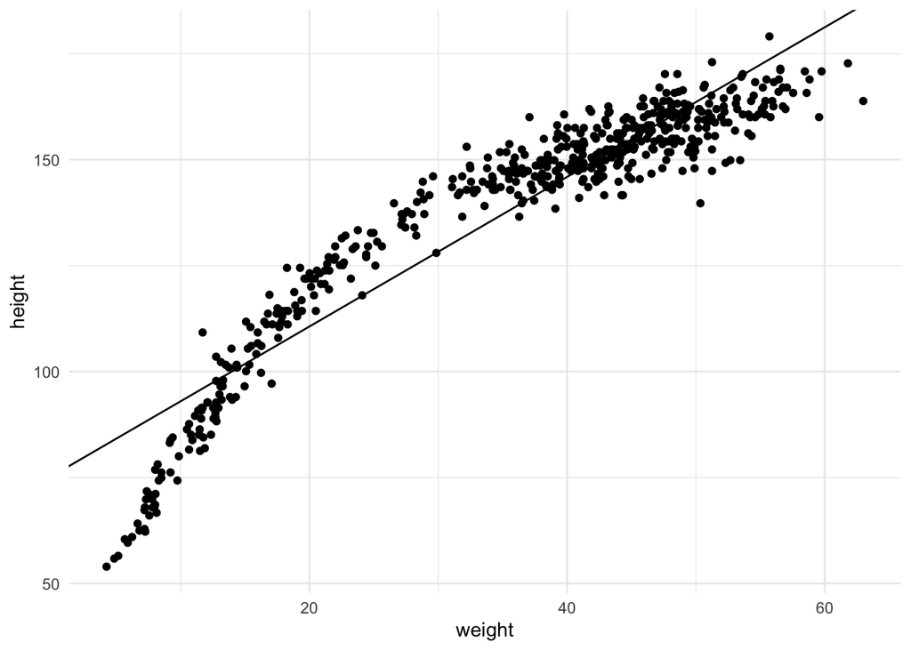

```r
ggplot(Howell1, aes(x=weight, y=height)) + geom_point() + theme_minimal() + geom_abline(slope=fit['b'], intercept=fit['a'])
```

3. Plotting this model will likely reveal it to be inadequate, because there is a substantial “curve” in the height-weight relationship. Repeat the exercise for #2, but update your model to better predict height. Possible approaches might include filtering the data (but I encourage you to use it all if possible), writing a curvilinear equation, or adding additional predictors. Compare the results of your attempts, and choose a single model that you think works “best.” Repeat a-e above for this model. Note any changes in the relationship between height and weight caused by your changes to the model. Additionally:

> Many models are possible. I show two; adding a curve by fitting the log weight, one more complicated, using a categorical variable for whether someone is an adult

```r
log_posterior_1 = function(params, data) {
    # unpack params and data
    height = data[['height']]
    weight = data[['weight']]
    a = params['a']
    b = params['b']
    s = exp(params['log_s']) ## we use log_s to help normalize the shape of the posterior

    # likelihood
    mu = a + b*log(weight)
    prob = sum(dnorm(height, mu, s, log=TRUE))

    # prior
    prob = prob +
        dnorm(a, 0, 50, log=TRUE) +
        dnorm(b, 0, 20, log=TRUE) +
        dexp(s, 0.2, log=TRUE)
}

log_posterior_2 = function(params, data) {
    # unpack params and data
    height = data[['height']]
    weight = data[['weight']]
    adult = data[['adult']]
    a1 = params['a1']
    a2 = params['a2']
    b1 = params['b1']
    b2 = params['b2']
    s = exp(params['log_s']) ## we use log_s to help normalize the shape of the posterior

    # likelihood
    mu = a1 + a2*adult + b1*weight + b2*weight*adult
    prob = sum(dnorm(height, mu, s, log=TRUE))

    # prior
    prob = prob +
        dnorm(a1, 0, 50, log=TRUE) +
        dnorm(a2, 0, 50, log=TRUE) +
        dnorm(b1, 0, 10, log=TRUE) +
        dnorm(b2, 0, 10, log=TRUE) +
        dexp(s, 0.2, log=TRUE)
}

Howell1$adult = ifelse(Howell1$age > 16, 1, 0)
fit1 = optim(c(a=0,b=20,log_s=0), log_posterior_1, method="Nelder-Mead",
             data =Howell1, control=list(fnscale=-1))$par

# lots of parameters, so I give it a better starting guess and more iterations
fit2 = optim(c(a1=20,a2=20,b1=5,b2=2,log_s=2), log_posterior_2, method="Nelder-Mead",
             data =Howell1, control=list(fnscale=-1, maxit=2000))$par
round(fit1, 3)
```

```
##       a       b   log_s
## -23.748  47.062   1.634
```

```r
round(fit2, 3)
```

```
##     a1     a2     b1     b2  log_s
## 55.631 58.499  2.894 -1.994  1.816
```

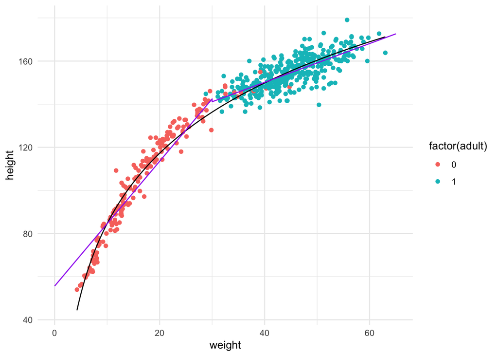

```r
curve = data.frame(x = seq(min(Howell1$weight), max(Howell1$weight), length.out=500))
curve$y = fit1['a'] + fit1['b']*log(curve$x)
linedat = data.frame(x = c(0,30, 30, 65), adult = c(0,0,1,1))
linedat$y = with(linedat, fit2['a1'] + fit2['a2']*adult + fit2['b1']*x + fit2['b2']*x*adult)
ggplot(Howell1, aes(x=weight, y=height, colour=factor(adult))) + geom_point() + theme_minimal() +
    geom_line(data = curve, aes(x=x,y=y), colour="black") +
    geom_line(data = linedat, aes(x=x, y=y), colour="purple")
```

6. Estimate the entire posterior using Laplace approximation

> I use only the first (curvilinear) regression

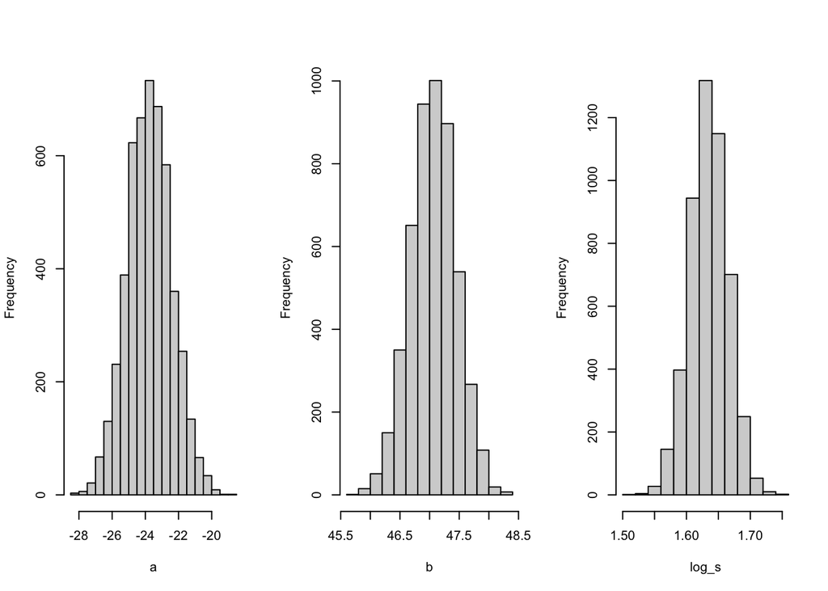

```r
fit = optim(c(a=20,b=5,log_s=2), log_posterior_1, method="Nelder-Mead",
             data =Howell1, control=list(fnscale=-1, maxit=2000), hessian=TRUE)
vcv = solve(-fit$hessian)
library(mvtnorm)
samples = rmvnorm(5000, fit$par, vcv)

par(mfrow=c(1,3))
for(i in 1:ncol(samples))
    hist(samples[,i], xlab=colnames(samples)[i], main="")
```

7. What are the credible intervals for the parameters of your model?

```r
round(t(apply(samples, 2, quantile, c(0.05, 0.95))),3)
```

```
##            5%     95%
## a     -25.936 -21.513
## b      46.424  47.682
## log_s   1.586   1.683
```

8. What is the probability that the height of a 24-year-old female with a weight of 41 kg is between 120 and 125 cm? What about for a male?

> To answer this, we need to do posterior predictive simulations on this case. Female/male is irrelevant, because it’s not in my model

```r
## compute mu for each sample
mu = samples[,'a'] + samples[,'b'] * log(41)

## draw a new posterior predictive sample for each mu and s
case_samples = rnorm(nrow(samples), mu, exp(samples[,'log_s']))
sum(case_samples >= 120 & case_samples <= 125)/length(case_samples)
```

```
## [1] 0
```

```r
## the prob is very small, so many samples needed for non-zero result
case_samples = mapply(function(m, s) rnorm(1000, m, s), m = mu, s = exp(samples[,'log_s']))
sum(case_samples >= 120 & case_samples <= 125)/length(case_samples)
```

```
## [1] 2e-07
```

1. Compute a posterior prediction interval for each case in the original dataset. You should have a median or MAP estimate and an interval for height along side the actual measured values for height from the original data. Plot the original height observations on the x-axis, and the predicted MAP/median on the y-axis. Experiment with the `segments` function to see if you can draw the predictions as vertical lines on the plot. What does this plot tell you about your model fit? What is the expected relationship for a “good” model?

> Here is a more general function for getting posterior simulations. This can be easily updated to change mu if the model changes, or to change rnorm if the likelihood function changes

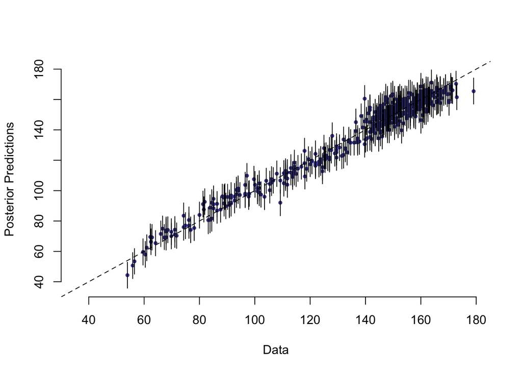

```r
#' Posterior predictive simulations
#' Produces n_sim simulations for a single set of parameters (i.e., not an entire posterior)
#' @param params A named parameter vector from the model
#' @param newdata x-variables (y not needed) for predictions
#' @return A matrix of simulated outcomes, each case in newdata is a column, each row is a simulation
ppsim = function(params, newdata) {
    mu = params['a'] + params['b']*log(newdata[['weight']])
    rnorm(length(mu), mu, exp(params['log_s']))
}

# ppsim works for one set of parameters, but we need to average across the whole posterior
# macs/unix/linux machines can do this more quickly using mclapply. Windows users can look at
# ?parallel::parLapply, but this is harder to use
# sims = do.call(rbind, parallel::mclapply(1:nrow(samples), function(i) {
#     ppsim(params = samples[i,], newdata = Howell1)
# }, mc.cores = 6))

## for single core machines
## output here gives one row per data point, one column per posterior simulation
sims = apply(samples, 1, ppsim, newdata = Howell1)

# here I compute 3 quantiles, to give a 90% interval and the median
predictions = apply(sims, 1, quantile, c(0.5, 0.05, 0.95))

# plot the median prediction against the original data
# I add the 1:1 line to show "perfect" predictions
lims = range(c(predictions, Howell1$height)) # compute the range of all predictions + data
plot(Howell1$height, predictions[1,], pch=16, cex=0.7, col="#444499", xlim=lims, ylim=lims, bty='n',
     xlab = "Data", ylab = "Posterior Predictions")
abline(0, 1, lty=2)

# and add segments to show the prediction intervals
segments(Howell1$height, predictions[2,], Howell1$height, predictions[3,])
```

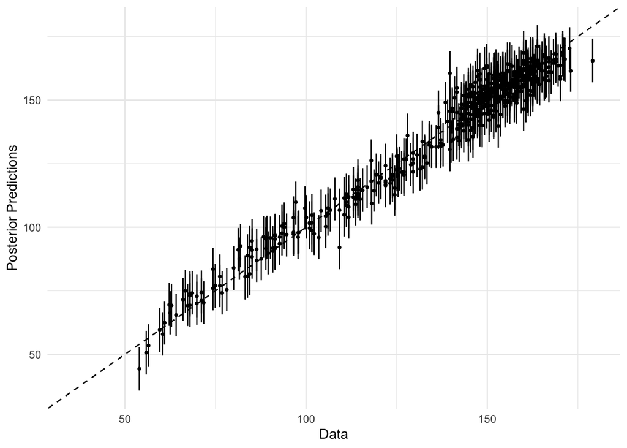

```r
## The same plot in ggplot
ggdat = data.frame(dat = Howell1$height, median = predictions[1,], lower = predictions[2,], upper = predictions[3,])
ggplot(ggdat, aes(x = dat, y = median)) +
    geom_errorbar(aes(ymin=lower, ymax=upper), width=0, size=0.5) +
    geom_point(size=0.8) +
    geom_abline(intercept=0, slope=1, lty=2) +
    theme_minimal() + xlab("Data") + ylab("Posterior Predictions") + xlim(lims[1], lims[2]) + ylim(lims[1], lims[2])
```

## Bonus

4. Return to one of the plots you made showing height against weight. It appears that the variance in height is not constant with respect to weight. This is one of the key assumptions in linear regression, and you probably made this implicitly in your model (the s parameter, the standard deviation, is constant). However, Bayesian models need not be so rigid.
   1. Can you design a model that allows the variance to increase as weight increases? Use whatever predictors for height that you think are best.
   2. Fit the model and compare the fit to your original model.
5. Buried in the bottom of a field notebook, you find two cases that were missing from the original dataset. The first is an individual with a weight of 43.72; no height, age, or sex data is recorded. The second is a 38-year-old female with a height of 135.
   1. Using the model from #3 above, can you predict a 90% credible interval for height of the first missing case? Is it easier if you use the model from #2?
   2. The second missing case is more interesting; we have the outcome of our model, but we are missing the weight. How could you estimate a 90% CI for weight, using the model from #3 (i.e., keeping height as the response variable)?

> We can build simple hierarchical where weight is a *random* variable described by *hyperparameters*, even though we still maintain the dependence of height on weight:

Graphically:

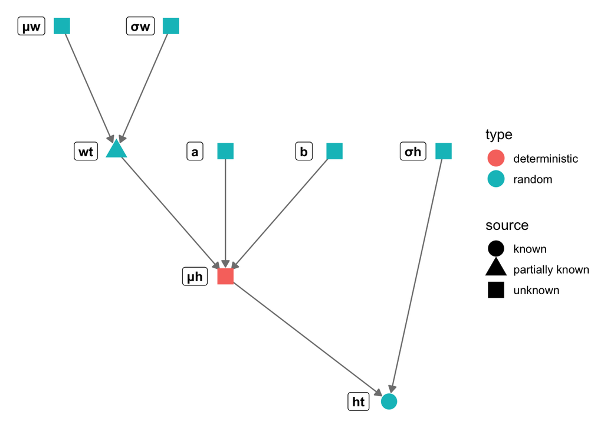

> Practically, to implement this, we need to treat the missing case as a *parameter* in our model, and sample from its posterior the same way we sample other posteriors.

```r
log_posterior_5b = function(params, data) {
    # unpack params and data
    height = data[['height']] # one longer than weight, missing case is on the end
    weight = data[['weight']] # last value is NA
    a = params['a']
    b = params['b']
    s = exp(params['log_s']) ## we use log_s to help normalize the shape of the posterior
    wt_missing = params['w']
    mu_wt = params['mu_w']
    s_wt = exp(params['log_s_w'])

    # add the missing case to the end of the weight vector
    weight[length(weight)] = wt_missing

    # likelihood for height
    mu = a + b*log(weight)
    prob = sum(dnorm(height, mu, s, log=TRUE))

    # likelihood for weight
    prob = prob + sum(dnorm(weight, mu_wt, s_wt, log = TRUE))

    # prior
    prob +
        dnorm(a, 0, 50, log=TRUE) +
        dnorm(b, 0, 20, log=TRUE) +
        dexp(s, 0.2, log=TRUE)  +
        dnorm(mu_wt, 0, 50, log = TRUE) +
        dexp(s_wt, 0.2, log = TRUE)
}

# initial values for all unknowns
inits = c(a = -20, b = 40, log_s = 1.5, w = 20, mu_w = mean(Howell1$weight, na.rm = TRUE),
    log_s_w = log(sd(Howell1$weight, na.rm = TRUE)))

## add the new case
Howell1 = rbind(Howell1, data.table(height = 135, weight = NA, age = 38, male = 0, adult = 1))
fit5a = optim(inits, log_posterior_5b, method="Nelder-Mead",
             data =Howell1, control=list(fnscale=-1), hessian = TRUE)
```

The new fit is quite similar to our old fit (we’ve added a data point, so it is expected that it changes slightly), but now we have an estimate of the missing weight, which we named ‘w’ in the parameter vector. We can also see that it is quite far away from the *marginal* mean weight, so we’re taking into account that this is a shorter than average individual.

```r
round(rbind(fit1 = c(fit1, w = NA, mu_w = NA, log_s_w = NA), fit5a = fit5a$par), 3)
```

```
##             a      b log_s      w   mu_w log_s_w
## fit1  -23.748 47.062 1.634     NA     NA      NA
## fit5a -24.897 47.390 1.635 25.095 35.448   2.685
```

We can learn more about this individual’s weight, plot it, etc by sampling from the posterior as before.

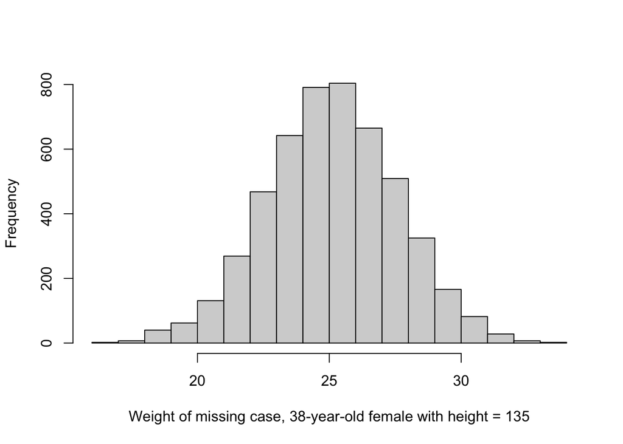

```r
vcv = solve(-fit5a$hessian)
samples = rmvnorm(5000, fit5a$par, vcv)

hist(samples[,4], xlab="Weight of missing case, 38-year-old female with height = 135", main="")
```

The posterior is symmetric, so an easy credible interval is:

```r
round(quantile(samples[,4], c(0.05, 0.95)), 3)
```

```
##     5%    95%
## 21.034 29.143
```

> Finally, we can do posterior predictive simulations on this case, taking into account all of the error in both height and weight.

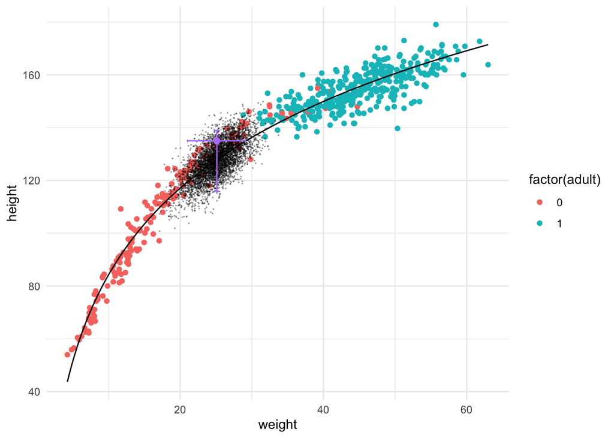

```r
## for each posterior estimate of w, we draw a new value for height
sims = apply(samples, 1, function(sa) {
    a = sa[1]
    b = sa[2]
    s = exp(sa[3])
    wt = sa[4]
    rnorm(1, a + b * log(wt), s)
})

simsdf = data.frame(height = sims, weight = samples[,4])
## drop the missing row for plotting
hw_plot = Howell1[complete.cases(Howell1)]

## separate data.frame for the missing case, adding posterior predictions
m_case = Howell1[!complete.cases(Howell1)]
m_case$weight = quantile(samples[,4], 0.5) ## posterior median for the prediction
m_case$lower_w = quantile(samples[,4], 0.05)
m_case$upper_w = quantile(samples[,4], 0.95)
m_case$lower_h = quantile(sims, 0.05)
m_case$upper_h = quantile(sims, 0.95)

## x-y locations for the curve fit
curve = data.frame(x = seq(min(hw_plot$weight), max(hw_plot$weight),
        length.out=500))
curve$y = fit5a$par['a'] + fit5a$par['b']*log(curve$x)

ggplot(hw_plot, aes(x=weight, y=height, colour=factor(adult))) + geom_point() +
    theme_minimal() + geom_line(data = curve, aes(x=x,y=y), colour="black") +
    geom_point(data = simsdf, aes(x = weight, y = height), colour = 'black', size = 0.02, alpha = 0.3) +
    geom_point(data = m_case, aes(x = weight, y = height), colour = '#b983ff',
            size = 2) +
    geom_errorbar(data = m_case, aes(y = height, xmin = lower_w, xmax = upper_w),
            colour = '#b983ff') +
    geom_errorbar(data = m_case, aes(x = weight, ymin = lower_h, ymax = upper_h),
            colour = '#b983ff')
```

6. Look at slide 15 from the inference lecture. Many people have trouble understanding why we add a column of 1s to the prediction dataset, and the `%*%` operator, and also the `apply` statement. Try the help file for both of them (use ?“%*%” to get help for the operator). Also run the code yourself and inspect the output.
   1. How many rows and columns are in `mu_samples`?
   2. How does this compare to the number of rows/columns in the inputs (`as.matrix(good_sample[,1:2])` and `t(x_predict)`)?
   3. What does each row in `mu_samples` represent? What about each column?
   4. What does `apply` do here?